# Parte II.

**Importamos librerias**

```python
import pandas as pd
import matplotlib.pyplot as plt
import numpy as np
import scipy.stats as stats
import seaborn as sns
```

**II.1. Separar el dataset en una parte que tenga variables independientes y otra la variable dependiente.**

```python
df = pd.read_csv("src/employee_attrition_dataset.csv")

independient_varibles = ["Age", "Gender", "Marital_Status"]
dependient_variables = ["Department",
    "Job_Role", "Job_Level", "Monthly_Income", "Hourly_Rate", "Years_at_Company",
    "Years_in_Current_Role", "Years_Since_Last_Promotion", "Work_Life_Balance",
    "Job_Satisfaction", "Performance_Rating", "Training_Hours_Last_Year", "Overtime",
    "Project_Count", "Average_Hours_Worked_Per_Week", "Absenteeism",
    "Work_Environment_Satisfaction", "Relationship_with_Manager", "Job_Involvement",
    "Distance_From_Home", "Number_of_Companies_Worked", "Attrition"
]

x = df[independient_varibles]
y = df[dependient_variables]
```

**II.2. Cambiar cada dato faltante de cada variable numérica por el promedio de los demás datos.**

```python
cols_num = df.select_dtypes(include="number").columns
for e in cols_num:
    promedio = df[e].mean()
    df[e].fillna(promedio, inplace=True)
```

# Parte III

**III.1. Cambiar a forma numérica las variables categóricas independientes.**

```python
print(df)
```

```
     Employee_ID  Age  Gender Marital_Status Department   Job_Role  Job_Level  \
0              1   58  Female        Married         IT    Manager          1
1              2   48  Female        Married      Sales  Assistant          5
2              3   34    Male        Married  Marketing  Assistant          1
3              4   27  Female       Divorced  Marketing    Manager          1
4              5   40    Male       Divorced  Marketing  Executive          1
..           ...  ...     ...            ...        ...        ...        ...
995          996   27  Female       Divorced         HR    Analyst          2
996          997   47    Male         Single         IT    Manager          4
997          998   50  Female       Divorced         IT  Executive          1
998          999   28  Female        Married         HR  Executive          4
999         1000   48  Female       Divorced         IT    Analyst          2

     Monthly_Income  Hourly_Rate  Years_at_Company  ...  Overtime  \
0             15488           28                15  ...        No
```

[output cut: 51 more lines]

```python
# Genero (variable categorica independiente)
df["Gender"] = df["Gender"].astype("category")
df["Gender"] = df["Gender"].cat.codes

# Marital_Status
df["Marital_Status"] = df["Marital_Status"].astype("category")
df["Marital_Status"] = df["Marital_Status"].cat.codes

print(df)
```

```
     Employee_ID  Age  Gender  Marital_Status Department   Job_Role  \
0              1   58       0               1         IT    Manager
1              2   48       0               1      Sales  Assistant
2              3   34       1               1  Marketing  Assistant
3              4   27       0               0  Marketing    Manager
4              5   40       1               0  Marketing  Executive
..           ...  ...     ...             ...        ...        ...
995          996   27       0               0         HR    Analyst
996          997   47       1               2         IT    Manager
997          998   50       0               0         IT  Executive
998          999   28       0               1         HR  Executive
999         1000   48       0               0         IT    Analyst

     Job_Level  Monthly_Income  Hourly_Rate  Years_at_Company  ...  Overtime  \
0            1           15488           28                15  ...        No
```

[output cut: 51 more lines]

```python
print(len(df.index))
```

```
1000
```

**III.3. Aplicar por lo menos 5 técnicas de limpieza de datos, o las que sean necesarias para hacer los siguientes puntos**

> La limpieza de datos es importante para evitar errores a futuro de entrenamiento de tecnologías o analisis de datos
1. Para comenzar eliminaremos valores duplicados con la funcion de pandas `drop_duplicates()`

```python
df = df.drop_duplicates()
print(len(df.index))
```

```
1000
```

2. Tambien eliminaremos valores nulos

```python
df = df.dropna() # Eliminar las filas con valores nulos
print(len(df.index))
```

```
1000
```

# Parte IV

**IV.1. Determinar si las variables numéricas tienen valores atípicos.**

```python
Q1 = df["Age"].quantile(0.25)
Q3 = df["Age"].quantile(0.75)

IQR = Q3 - Q1
limite_inferior = Q1 - 1.5 * IQR
limite_superior = Q3 + 1.5 * IQR

df = df[(df["Age"] >= limite_inferior) & (df["Age"] <= limite_superior)]
print(df)
```

```
     Employee_ID  Age  Gender  Marital_Status Department   Job_Role  \
0              1   58       0               1         IT    Manager
1              2   48       0               1      Sales  Assistant
2              3   34       1               1  Marketing  Assistant
3              4   27       0               0  Marketing    Manager
4              5   40       1               0  Marketing  Executive
..           ...  ...     ...             ...        ...        ...
995          996   27       0               0         HR    Analyst
996          997   47       1               2         IT    Manager
997          998   50       0               0         IT  Executive
998          999   28       0               1         HR  Executive
999         1000   48       0               0         IT    Analyst

     Job_Level  Monthly_Income  Hourly_Rate  Years_at_Company  ...  Overtime  \
0            1           15488           28                15  ...        No
```

[output cut: 51 more lines]

```python
Q1 = df["Hourly_Rate"].quantile(0.25)
Q3 = df["Hourly_Rate"].quantile(0.75)

IQR = Q3 - Q1
limite_inferior = Q1 - 1.5 * IQR
limite_superior = Q3 + 1.5 * IQR

df = df[(df["Hourly_Rate"] >= limite_inferior) & (df["Hourly_Rate"] <= limite_superior)]
```

```python
Q1 = df["Years_at_Company"].quantile(0.25)
Q3 = df["Years_at_Company"].quantile(0.75)

IQR = Q3 - Q1
limite_inferior = Q1 - 1.5 * IQR
limite_superior = Q3 + 1.5 * IQR

df = df[(df["Years_at_Company"] >= limite_inferior) & (df["Years_at_Company"] <= limite_superior)]
```

```python
Q1 = df["Years_in_Current_Role"].quantile(0.25)
Q3 = df["Years_in_Current_Role"].quantile(0.75)

IQR = Q3 - Q1
limite_inferior = Q1 - 1.5 * IQR
limite_superior = Q3 + 1.5 * IQR

df = df[(df["Years_in_Current_Role"] >= limite_inferior) & (df["Years_in_Current_Role"] <= limite_superior)]
```

```python
print(df)
```

```
     Employee_ID  Age  Gender  Marital_Status Department   Job_Role  \
0              1   58       0               1         IT    Manager
1              2   48       0               1      Sales  Assistant
2              3   34       1               1  Marketing  Assistant
3              4   27       0               0  Marketing    Manager
4              5   40       1               0  Marketing  Executive
..           ...  ...     ...             ...        ...        ...
995          996   27       0               0         HR    Analyst
996          997   47       1               2         IT    Manager
997          998   50       0               0         IT  Executive
998          999   28       0               1         HR  Executive
999         1000   48       0               0         IT    Analyst

     Job_Level  Monthly_Income  Hourly_Rate  Years_at_Company  ...  Overtime  \
0            1           15488           28                15  ...        No
```

[output cut: 51 more lines]

# Parte V

**Estandarizar las variables numericas** Para este paso hemos de hacerlo columna por columna como en el anterior paso. Para ello nos guiaremos de la siguiente formula: $$z = \frac{(X-\mu)}{\sigma}$$

En codigo quedaría de la siguiente manera:

```python
df["Hourly_Rate"] = (df["Hourly_Rate"] - df["Hourly_Rate"].mean()) / df["Hourly_Rate"].std()
df["Years_at_Company"] = (df["Years_at_Company"] - df["Years_at_Company"].mean()) / df["Years_at_Company"].std()
df["Years_in_Current_Role"] = (df["Years_in_Current_Role"] - df["Years_in_Current_Role"].mean()) / df["Years_in_Current_Role"].std()
df["Years_Since_Last_Promotion"] = (df["Years_Since_Last_Promotion"] - df["Years_Since_Last_Promotion"].mean()) / df["Years_Since_Last_Promotion"].std()
df["Work_Life_Balance"] = (df["Work_Life_Balance"] - df["Work_Life_Balance"].mean()) / df["Work_Life_Balance"].std()
df["Job_Satisfaction"] = (df["Job_Satisfaction"] - df["Job_Satisfaction"].mean()) / df["Job_Satisfaction"].std()
df["Performance_Rating"] = (df["Performance_Rating"] - df["Performance_Rating"].mean()) / df["Performance_Rating"].std()
df["Training_Hours_Last_Year"] = (df["Training_Hours_Last_Year"] - df["Training_Hours_Last_Year"].mean()) / df["Training_Hours_Last_Year"].std()
df["Project_Count"] = (df["Project_Count"] - df["Project_Count"].mean()) / df["Project_Count"].std()
df["Average_Hours_Worked_Per_Week"] = (df["Average_Hours_Worked_Per_Week"] - df["Average_Hours_Worked_Per_Week"].mean()) / df["Average_Hours_Worked_Per_Week"].std()
df["Absenteeism"] = (df["Absenteeism"] - df["Absenteeism"].mean()) / df["Absenteeism"].std()
```

# Parte VI

VI.1. Generar un nuevo dataset con los cambios realizados en las variables categóricas y las variables numéricas en las partes anteriores

```python
df.to_csv("new_employee_attrition_dataset.csv", index=False)
```

**VI.2. Realizar un análisis estadístico exploratorio de los datos obtenidos en el inciso VI.1 que contenga por lo menos lo siguiente:**

A) Número de valores por cada variable numérica transformada vs el número de valores de cada variable numérica original en una tabla

```python
# Creamos el nuevo data frame para el nuevo dataset
new_df = pd.read_csv("new_employee_attrition_dataset.csv")
old_df = pd.read_csv("src/employee_attrition_dataset.csv")

new_count = new_df.select_dtypes(include=np.number).count()
original_count = old_df.select_dtypes(include=np.number).count()

comparasion_df = pd.DataFrame({"original": original_count, "new": new_count})
print(comparasion_df)
```

```
                               original   new
Absenteeism                      1000.0  1000
Age                              1000.0  1000
Average_Hours_Worked_Per_Week    1000.0  1000
Distance_From_Home               1000.0  1000
Employee_ID                      1000.0  1000
Gender                              NaN  1000
Hourly_Rate                      1000.0  1000
Job_Involvement                  1000.0  1000
Job_Level                        1000.0  1000
Job_Satisfaction                 1000.0  1000
Marital_Status                      NaN  1000
Monthly_Income                   1000.0  1000
Number_of_Companies_Worked       1000.0  1000
Performance_Rating               1000.0  1000
Project_Count                    1000.0  1000
Relationship_with_Manager        1000.0  1000
Training_Hours_Last_Year         1000.0  1000
Work_Environment_Satisfaction    1000.0  1000
Work_Life_Balance                1000.0  1000
Years_Since_Last_Promotion       1000.0  1000
Years_at_Company                 1000.0  1000
Years_in_Current_Role            1000.0  1000
```

**b) Medidas de tendencia central de cada variable numérica transformada**

```python
# Primeramente tomamos las variables numericas (todas)
df_numeric = df.select_dtypes(include="number")

# Creamos un data frame que contenga las medidas de tendencia central
medidas_tendencia_central = pd.DataFrame({
    "Variable": df_numeric.columns,
    "Media": df_numeric.mean(),
    "Mediana": df_numeric.median(),
    "Moda": df_numeric.mode().iloc[0]  # Tomamos la primera moda en caso de múltiples
})

#imprimimos
print(medidas_tendencia_central)
```

```
                                                    Variable         Media  \
Employee_ID                                      Employee_ID  5.005000e+02
Age                                                      Age  3.999100e+01
Gender                                                Gender  5.160000e-01
Marital_Status                                Marital_Status  1.026000e+00
Job_Level                                          Job_Level  3.055000e+00
Monthly_Income                                Monthly_Income  1.149990e+04
Hourly_Rate                                      Hourly_Rate -1.394440e-16
Years_at_Company                            Years_at_Company -6.838974e-17
Years_in_Current_Role                  Years_in_Current_Role  6.039613e-17
Years_Since_Last_Promotion        Years_Since_Last_Promotion -1.136868e-16
Work_Life_Balance                          Work_Life_Balance -7.993606e-17
Job_Satisfaction                            Job_Satisfaction  2.131628e-16
Performance_Rating                        Performance_Rating -1.088019e-16
Training_Hours_Last_Year            Training_Hours_Last_Year  3.552714e-17
Project_Count                                  Project_Count  9.237056e-17
Average_Hours_Worked_Per_Week  Average_Hours_Worked_Per_Week  2.877698e-16
Absenteeism                                      Absenteeism  1.634248e-16
Work_Environment_Satisfaction  Work_Environment_Satisfaction  2.494000e+00
Relationship_with_Manager          Relationship_with_Manager  2.519000e+00
Job_Involvement                              Job_Involvement  2.503000e+00
Distance_From_Home                        Distance_From_Home  2.450700e+01
Number_of_Companies_Worked        Number_of_Companies_Worked  2.484000e+00

                                    Mediana         Moda
Employee_ID                      500.500000     1.000000
Age                               41.000000    52.000000
Gender                             1.000000     1.000000
Marital_Status                     1.000000     1.000000
Job_Level                          3.000000     5.000000
Monthly_Income                 11256.000000  3534.000000
Hourly_Rate                        0.006599     0.573354
Years_at_Company                   0.009341     0.368599
Years_in_Current_Role              0.115219     0.615087
Years_Since_Last_Promotion        -0.136223    -1.471747
Work_Life_Balance                  0.456982     0.456982
Job_Satisfaction                  -0.105819     1.295755
Performance_Rating                 0.418314     1.302699
Training_Hours_Last_Year          -0.001525     1.062130
Project_Count                      0.048295    -1.129638
Average_Hours_Worked_Per_Week      0.051355    -0.982630
Absenteeism                       -0.087720    -1.594366
Work_Environment_Satisfaction      2.000000     2.000000
Relationship_with_Manager          3.000000     2.000000
Job_Involvement                    3.000000     3.000000
Distance_From_Home                24.000000    13.000000
Number_of_Companies_Worked         2.000000     3.000000
```

**c) Medidas de dispersión de cada variable numérica transformada**

```python
numeric_columns = df.select_dtypes(include=[np.number]).columns

medidas_dispercion = pd.DataFrame({
    'Variable': numeric_columns,
    'Rango': df[numeric_columns].max() - df[numeric_columns].min(),
    'Varianza': df[numeric_columns].var(),
    'Desviación Estándar': df[numeric_columns].std(),
    'Coeficiente de Variación': (df[numeric_columns].std() / df[numeric_columns].mean()) * 100,
    'IQR': df[numeric_columns].quantile(0.75) - df[numeric_columns].quantile(0.25)
})

print(medidas_dispercion)
```

```
                                                    Variable         Rango  \
Employee_ID                                      Employee_ID    999.000000
Age                                                      Age     39.000000
Gender                                                Gender      1.000000
Marital_Status                                Marital_Status      2.000000
Job_Level                                          Job_Level      4.000000
Monthly_Income                                Monthly_Income  16998.000000
Hourly_Rate                                      Hourly_Rate      3.400529
Years_at_Company                            Years_at_Company      3.353073
Years_in_Current_Role                  Years_in_Current_Role      3.249138
Years_Since_Last_Promotion        Years_Since_Last_Promotion      3.004928
Work_Life_Balance                          Work_Life_Balance      2.714742
Job_Satisfaction                            Job_Satisfaction      2.803148
Performance_Rating                        Performance_Rating      2.653154
Training_Hours_Last_Year            Training_Hours_Last_Year      3.510059
Project_Count                                  Project_Count      3.141156
Average_Hours_Worked_Per_Week  Average_Hours_Worked_Per_Week      3.331728
Absenteeism                                      Absenteeism      3.180697
Work_Environment_Satisfaction  Work_Environment_Satisfaction      3.000000
Relationship_with_Manager          Relationship_with_Manager      3.000000
Job_Involvement                              Job_Involvement      3.000000
Distance_From_Home                        Distance_From_Home     48.000000
Number_of_Companies_Worked        Number_of_Companies_Worked      3.000000

                                   Varianza  Desviación Estándar  \
Employee_ID                    8.341667e+04           288.819436
Age                            1.387697e+02            11.780055
Gender                         2.499940e-01             0.499994
Marital_Status                 6.519760e-01             0.807450
Job_Level                      1.959935e+00             1.399977
Monthly_Income                 2.421161e+07          4920.529231
Hourly_Rate                    1.000000e+00             1.000000
Years_at_Company               1.000000e+00             1.000000
Years_in_Current_Role          1.000000e+00             1.000000
Years_Since_Last_Promotion     1.000000e+00             1.000000
Work_Life_Balance              1.000000e+00             1.000000
Job_Satisfaction               1.000000e+00             1.000000
Performance_Rating             1.000000e+00             1.000000
Training_Hours_Last_Year       1.000000e+00             1.000000
Project_Count                  1.000000e+00             1.000000
```

[output cut: 16 more lines]

```
Years_at_Company                          -1.462208e+18     1.676537
Years_in_Current_Role                      1.655735e+18     1.749536
Years_Since_Last_Promotion                -8.796093e+17     1.669404
Work_Life_Balance                         -1.251000e+18     0.904914
Job_Satisfaction                           4.691250e+17     1.401574
Performance_Rating                        -9.191020e+17     1.768769
Training_Hours_Last_Year                   2.814750e+18     1.746166
Project_Count                              1.082596e+18     1.570578
Average_Hours_Worked_Per_Week              3.475000e+17     1.723308
Absenteeism                                6.119021e+17     1.841456
Work_Environment_Satisfaction              4.452663e+01     2.000000
Relationship_with_Manager                  4.393552e+01     2.000000
Job_Involvement                            4.393274e+01     1.000000
Distance_From_Home                         5.769004e+01    25.000000
Number_of_Companies_Worked                 4.473817e+01     2.000000
```

**d) Medidas de posición de cada variable numérica transformada**

```python
medidas_posicion = pd.DataFrame({
    'Variable': numeric_columns,
    'Media': df[numeric_columns].mean(),
    'Mediana': df[numeric_columns].median(),
    'Moda': df[numeric_columns].mode().iloc[0],  # Tomamos la primera moda si hay múltiples
    'Percentil 25': df[numeric_columns].quantile(0.25),
    'Percentil 50 (Mediana)': df[numeric_columns].quantile(0.50),
    'Percentil 75': df[numeric_columns].quantile(0.75),
    'Mínimo': df[numeric_columns].min(),
    'Máximo': df[numeric_columns].max()
})

print(medidas_posicion)
```

```
                                                    Variable         Media  \
Employee_ID                                      Employee_ID  5.005000e+02
Age                                                      Age  3.999100e+01
Gender                                                Gender  5.160000e-01
Marital_Status                                Marital_Status  1.026000e+00
Job_Level                                          Job_Level  3.055000e+00
Monthly_Income                                Monthly_Income  1.149990e+04
Hourly_Rate                                      Hourly_Rate -1.394440e-16
Years_at_Company                            Years_at_Company -6.838974e-17
Years_in_Current_Role                  Years_in_Current_Role  6.039613e-17
Years_Since_Last_Promotion        Years_Since_Last_Promotion -1.136868e-16
Work_Life_Balance                          Work_Life_Balance -7.993606e-17
Job_Satisfaction                            Job_Satisfaction  2.131628e-16
Performance_Rating                        Performance_Rating -1.088019e-16
Training_Hours_Last_Year            Training_Hours_Last_Year  3.552714e-17
Project_Count                                  Project_Count  9.237056e-17
Average_Hours_Worked_Per_Week  Average_Hours_Worked_Per_Week  2.877698e-16
Absenteeism                                      Absenteeism  1.634248e-16
Work_Environment_Satisfaction  Work_Environment_Satisfaction  2.494000e+00
Relationship_with_Manager          Relationship_with_Manager  2.519000e+00
Job_Involvement                              Job_Involvement  2.503000e+00
Distance_From_Home                        Distance_From_Home  2.450700e+01
Number_of_Companies_Worked        Number_of_Companies_Worked  2.484000e+00

                                    Mediana         Moda  Percentil 25  \
Employee_ID                      500.500000     1.000000    250.750000
Age                               41.000000    52.000000     30.000000
Gender                             1.000000     1.000000      0.000000
Marital_Status                     1.000000     1.000000      0.000000
Job_Level                          3.000000     5.000000      2.000000
Monthly_Income                 11256.000000  3534.000000   7395.750000
Hourly_Rate                        0.006599     0.573354     -0.884016
Years_at_Company                   0.009341     0.368599     -0.828928
Years_in_Current_Role              0.115219     0.615087     -0.884515
Years_Since_Last_Promotion        -0.136223    -1.471747     -0.803985
Work_Life_Balance                  0.456982     0.456982     -0.447932
Job_Satisfaction                  -0.105819     1.295755     -0.806606
Performance_Rating                 0.418314     1.302699     -0.466071
Training_Hours_Last_Year          -0.001525     1.062130     -0.852448
Project_Count                      0.048295    -1.129638     -0.736994
```

[output cut: 40 more lines]

```
Years_at_Company                 -1.667196      1.685877
Years_in_Current_Role            -1.634317      1.614822
Years_Since_Last_Promotion       -1.471747      1.533181
Work_Life_Balance                -1.352846      1.361895
Job_Satisfaction                 -1.507393      1.295755
Performance_Rating               -1.350455      1.302699
Training_Hours_Last_Year         -1.774281      1.735777
Project_Count                    -1.522283      1.618873
Average_Hours_Worked_Per_Week    -1.671953      1.659775
Absenteeism                      -1.594366      1.586331
Work_Environment_Satisfaction     1.000000      4.000000
Relationship_with_Manager         1.000000      4.000000
Job_Involvement                   1.000000      4.000000
Distance_From_Home                1.000000     49.000000
Number_of_Companies_Worked        1.000000      4.000000
```

**e) Sesgo y curtosis de cada variable numérica transformada**

```python
sesgo_curtosis = pd.DataFrame({
    'Variable': numeric_columns,
    'Sesgo': df[numeric_columns].apply(stats.skew),  # Calcula el sesgo
    'Curtosis': df[numeric_columns].apply(stats.kurtosis)  # Calcula la curtosis
})

print(sesgo_curtosis)
```

```
                                                    Variable     Sesgo  \
Employee_ID                                      Employee_ID  0.000000
Age                                                      Age -0.090289
Gender                                                Gender -0.064033
Marital_Status                                Marital_Status -0.047219
Job_Level                                          Job_Level -0.043154
Monthly_Income                                Monthly_Income  0.028714
Hourly_Rate                                      Hourly_Rate -0.054231
Years_at_Company                            Years_at_Company  0.004385
Years_in_Current_Role                  Years_in_Current_Role -0.063442
Years_Since_Last_Promotion        Years_Since_Last_Promotion  0.017563
Work_Life_Balance                          Work_Life_Balance -0.011837
Job_Satisfaction                            Job_Satisfaction -0.150945
Performance_Rating                        Performance_Rating -0.021287
Training_Hours_Last_Year            Training_Hours_Last_Year -0.057380
Project_Count                                  Project_Count  0.064137
Average_Hours_Worked_Per_Week  Average_Hours_Worked_Per_Week -0.006511
Absenteeism                                      Absenteeism  0.002107
Work_Environment_Satisfaction  Work_Environment_Satisfaction  0.043641
Relationship_with_Manager          Relationship_with_Manager -0.014779
Job_Involvement                              Job_Involvement -0.027960
Distance_From_Home                        Distance_From_Home  0.071852
Number_of_Companies_Worked        Number_of_Companies_Worked  0.014028

                               Curtosis
Employee_ID                   -1.200002
Age                           -1.243422
Gender                        -1.995900
Marital_Status                -1.463216
Job_Level                     -1.273333
Monthly_Income                -1.188320
Hourly_Rate                   -1.198387
Years_at_Company              -1.206282
Years_in_Current_Role         -1.166881
Years_Since_Last_Promotion    -1.306684
Work_Life_Balance             -1.329011
Job_Satisfaction              -1.305761
Performance_Rating            -1.387767
Training_Hours_Last_Year      -1.195059
Project_Count                 -1.209923
Average_Hours_Worked_Per_Week -1.202257
Absenteeism                   -1.274195
Work_Environment_Satisfaction -1.340510
Relationship_with_Manager     -1.332744
Job_Involvement               -1.315646
Distance_From_Home            -1.210287
Number_of_Companies_Worked    -1.343213
```

**f) Correlación entre pares de variables cuantitativas transformadas**

```
                               Employee_ID       Age    Gender  \
Employee_ID                       1.000000 -0.012222 -0.048696
Age                              -0.012222  1.000000 -0.049176
Gender                           -0.048696 -0.049176  1.000000
Marital_Status                    0.003009 -0.005342  0.003927
Job_Level                        -0.013340 -0.074931  0.093839
Monthly_Income                   -0.045417 -0.020251 -0.001516
Hourly_Rate                       0.040863  0.019844  0.045071
Years_at_Company                 -0.001709  0.016234  0.018041
Years_in_Current_Role            -0.032868 -0.012895 -0.054603
Years_Since_Last_Promotion       -0.034913 -0.025487 -0.015059
Work_Life_Balance                -0.016545  0.015798 -0.044241
Job_Satisfaction                 -0.020782 -0.069234  0.001521
Performance_Rating                0.006935  0.022826 -0.038832
Training_Hours_Last_Year          0.006736 -0.030696 -0.011583
Project_Count                    -0.031376  0.038766  0.003512
Average_Hours_Worked_Per_Week    -0.064954 -0.000498  0.053972
Absenteeism                       0.054185 -0.006846  0.018640
Work_Environment_Satisfaction    -0.047742  0.014190  0.000173
Relationship_with_Manager         0.014163  0.030303 -0.019544
Job_Involvement                   0.078447  0.004214 -0.088388
Distance_From_Home               -0.032465 -0.005220  0.061087
Number_of_Companies_Worked       -0.002367  0.010885 -0.037371

                               Marital_Status  Job_Level  Monthly_Income  \
Employee_ID                          0.003009  -0.013340       -0.045417
Age                                 -0.005342  -0.074931       -0.020251
Gender                               0.003927   0.093839       -0.001516
Marital_Status                       1.000000   0.043010       -0.053994
Job_Level                            0.043010   1.000000        0.036941
Monthly_Income                      -0.053994   0.036941        1.000000
Hourly_Rate                         -0.061065   0.038381       -0.056088
Years_at_Company                     0.027172  -0.021553       -0.045316
Years_in_Current_Role               -0.021384  -0.034784       -0.003193
Years_Since_Last_Promotion           0.032448   0.034033       -0.025036
Work_Life_Balance                    0.009120  -0.011792       -0.005465
Job_Satisfaction                    -0.010361  -0.046251        0.011808
Performance_Rating                   0.000327  -0.006314       -0.027322
Training_Hours_Last_Year             0.072343  -0.005739        0.005971
Project_Count                        0.043418   0.010883       -0.018164
```

[output cut: 186 more lines]

```
Years_Since_Last_Promotion               0.024872                    0.028729
Work_Life_Balance                       -0.045743                   -0.011884
Job_Satisfaction                         0.022995                    0.012572
Performance_Rating                      -0.007901                    0.059692
Training_Hours_Last_Year                 0.010795                   -0.027651
Project_Count                            0.020971                   -0.038009
Average_Hours_Worked_Per_Week            0.004113                   -0.019523
Absenteeism                              0.030145                    0.002923
Work_Environment_Satisfaction            0.007749                   -0.027656
Relationship_with_Manager                0.027628                   -0.004229
Job_Involvement                         -0.005345                   -0.009381
Distance_From_Home                       1.000000                    0.042725
Number_of_Companies_Worked               0.042725                    1.000000

[22 rows x 22 columns]
```

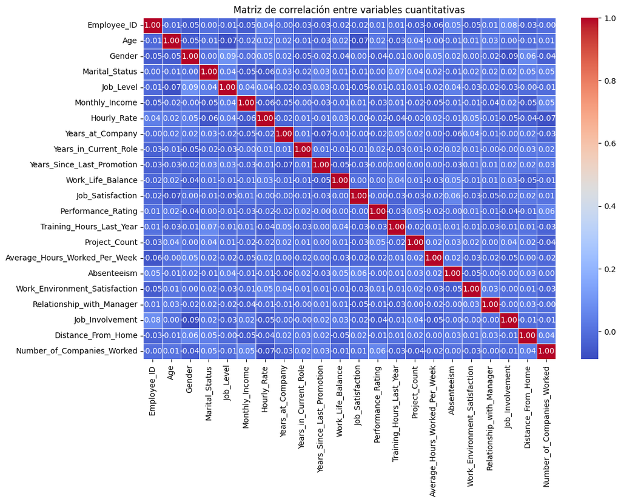

```python
# Preparamos la matriz de correlación
correlacion_matrix = df[numeric_columns].corr()
print(correlacion_matrix)

# Dibujamos la matriz de correlación
plt.figure(figsize=(12, 8))
sns.heatmap(correlacion_matrix, annot=True, cmap="coolwarm", fmt=".2f", linewidths=0.5)
plt.title("Matriz de correlación entre variables cuantitativas")
plt.show()
```

**h) Diagramas de caja entre variables categóricas**

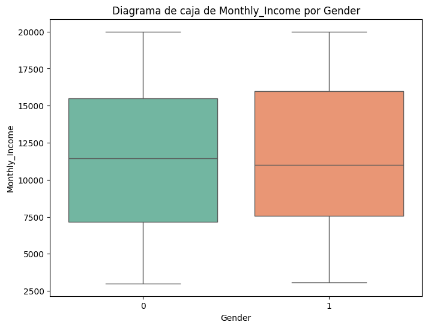

```python
categorical_variable = "Gender"  # Cambia por la variable categórica que desees
numerical_variable = "Monthly_Income"  # Cambia por la variable numérica que desees

# Crear el diagrama de caja
plt.figure(figsize=(8, 6))
sns.boxplot(x=categorical_variable, y=numerical_variable, data=df, palette="Set2")
plt.title(f"Diagrama de caja de {numerical_variable} por {categorical_variable}")
plt.xlabel(categorical_variable)
plt.ylabel(numerical_variable)
plt.show()
```

**i) Tablas de distribución de frecuencias de cada variable cuantitativa transformada**

```
Tabla de distribución de frecuencias para Employee_ID:
Employee_ID
(0.001, 100.9]     100
(100.9, 200.8]     100
(200.8, 300.7]     100
(300.7, 400.6]     100
(400.6, 500.5]     100
(500.5, 600.4]     100
(600.4, 700.3]     100
(700.3, 800.2]     100
(800.2, 900.1]     100
(900.1, 1000.0]    100
Name: count, dtype: int64
```

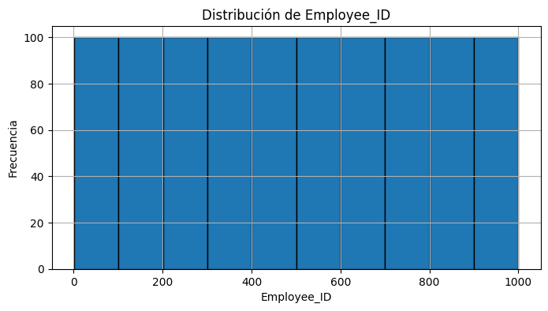

```
==================================================

Tabla de distribución de frecuencias para Age:
Age
(19.961, 23.9]    103
(23.9, 27.8]      101
(27.8, 31.7]       93
(31.7, 35.6]       88
(35.6, 39.5]       83
(39.5, 43.4]       97
(43.4, 47.3]      116
(47.3, 51.2]       95
(51.2, 55.1]      117
(55.1, 59.0]      107
Name: count, dtype: int64
```

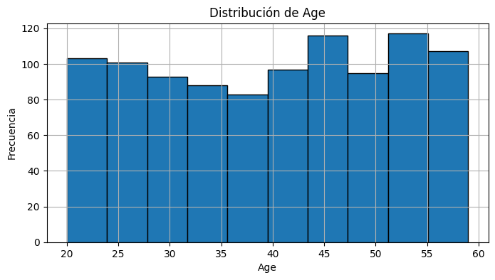

```
==================================================

Tabla de distribución de frecuencias para Gender:
Gender
(-0.001, 0.1]    484
(0.1, 0.2]         0
(0.2, 0.3]         0
(0.3, 0.4]         0
(0.4, 0.5]         0
(0.5, 0.6]         0
(0.6, 0.7]         0
(0.7, 0.8]         0
(0.8, 0.9]         0
(0.9, 1.0]       516
Name: count, dtype: int64
```

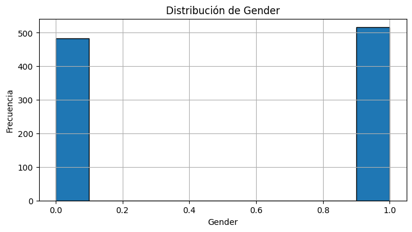

```
==================================================

Tabla de distribución de frecuencias para Marital_Status:
Marital_Status
(-0.002, 0.2]    313
(0.2, 0.4]         0
(0.4, 0.6]         0
(0.6, 0.8]         0
(0.8, 1.0]       348
(1.0, 1.2]         0
(1.2, 1.4]         0
(1.4, 1.6]         0
(1.6, 1.8]         0
(1.8, 2.0]       339
Name: count, dtype: int64
```

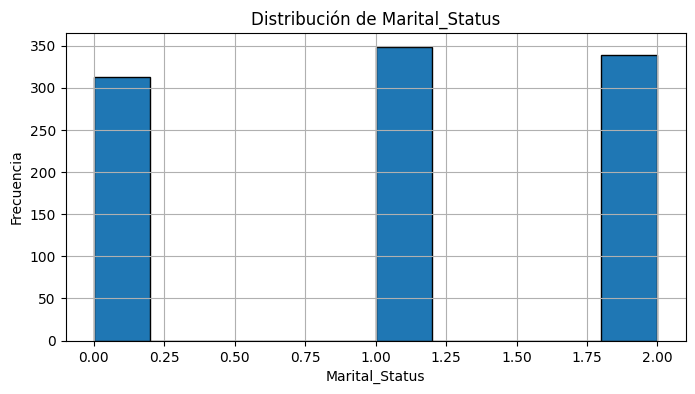

```
==================================================

Tabla de distribución de frecuencias para Job_Level:
Job_Level
(0.996, 1.4]    182
(1.4, 1.8]        0
(1.8, 2.2]      200
(2.2, 2.6]        0
(2.6, 3.0]      206
(3.0, 3.4]        0
(3.4, 3.8]        0
(3.8, 4.2]      205
(4.2, 4.6]        0
(4.6, 5.0]      207
Name: count, dtype: int64
```

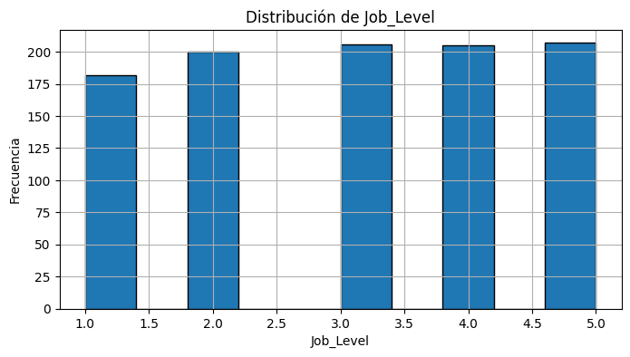

```
==================================================

Tabla de distribución de frecuencias para Monthly_Income:
Monthly_Income
(2984.002, 4700.8]    101
(4700.8, 6400.6]      101
(6400.6, 8100.4]       91
(8100.4, 9800.2]      112
(9800.2, 11500.0]     106
(11500.0, 13199.8]    100
(13199.8, 14899.6]     96
(14899.6, 16599.4]     81
(16599.4, 18299.2]    100
(18299.2, 19999.0]    112
Name: count, dtype: int64
```

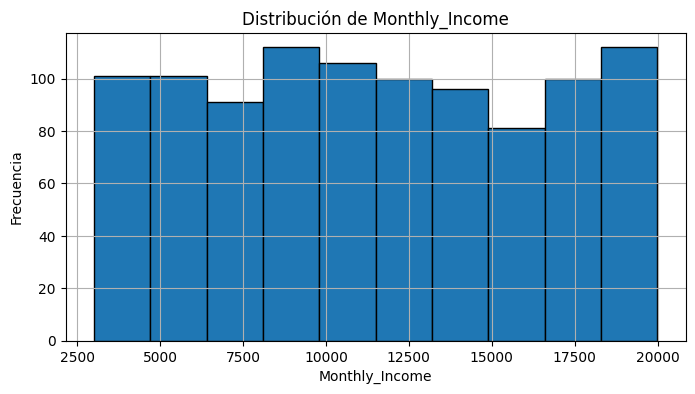

```
==================================================

Tabla de distribución de frecuencias para Hourly_Rate:
Hourly_Rate
(-1.738, -1.394]      99
(-1.394, -1.054]      98
(-1.054, -0.714]      99
(-0.714, -0.374]      79
(-0.374, -0.0339]    107
(-0.0339, 0.306]     100
(0.306, 0.646]       109
(0.646, 0.986]        94
(0.986, 1.326]       103
(1.326, 1.666]       112
Name: count, dtype: int64
```

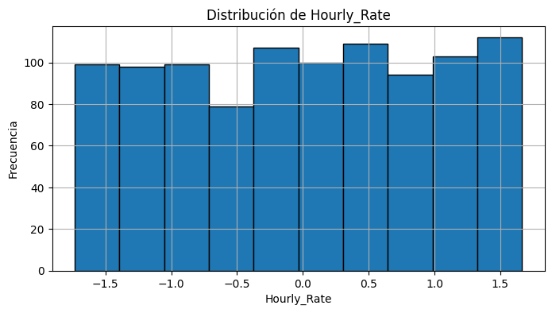

```
==================================================

Tabla de distribución de frecuencias para Years_at_Company:
Years_at_Company
(-1.671, -1.332]     113
(-1.332, -0.997]      94
(-0.997, -0.661]     104
(-0.661, -0.326]     111
(-0.326, 0.00934]     96
(0.00934, 0.345]      65
(0.345, 0.68]        110
(0.68, 1.015]        103
(1.015, 1.351]       108
(1.351, 1.686]        96
Name: count, dtype: int64
```

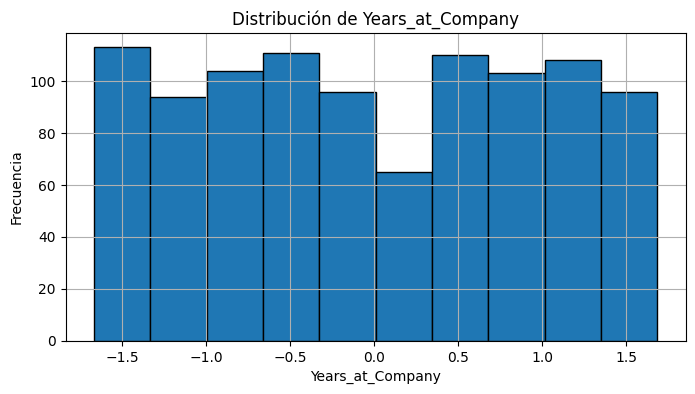

```
==================================================

Tabla de distribución de frecuencias para Years_in_Current_Role:
Years_in_Current_Role
(-1.638, -1.309]      152
(-1.309, -0.984]       53
(-0.984, -0.66]        71
(-0.66, -0.335]       135
(-0.335, -0.00975]     81
(-0.00975, 0.315]      68
(0.315, 0.64]         161
(0.64, 0.965]          73
(0.965, 1.29]          66
(1.29, 1.615]         140
Name: count, dtype: int64
```

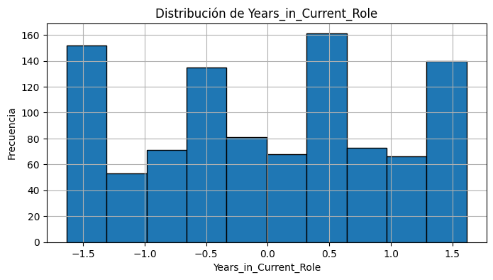

```
==================================================

Tabla de distribución de frecuencias para Years_Since_Last_Promotion:
Years_Since_Last_Promotion
(-1.475, -1.171]    135
(-1.171, -0.871]     88
(-0.871, -0.57]     101
(-0.57, -0.27]      101
(-0.27, 0.0307]      87
(0.0307, 0.331]      90
(0.331, 0.632]       89
(0.632, 0.932]       91
(0.932, 1.233]      116
(1.233, 1.533]      102
Name: count, dtype: int64
```

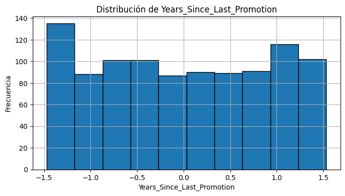

```
==================================================

Tabla de distribución de frecuencias para Work_Life_Balance:
Work_Life_Balance
(-1.356, -1.081]     248
(-1.081, -0.81]        0
(-0.81, -0.538]        0
(-0.538, -0.267]     246
(-0.267, 0.00452]      0
(0.00452, 0.276]       0
(0.276, 0.547]       269
(0.547, 0.819]         0
(0.819, 1.09]          0
(1.09, 1.362]        237
Name: count, dtype: int64
```

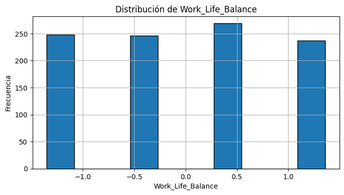

```
==================================================

Tabla de distribución de frecuencias para Job_Satisfaction:
Job_Satisfaction
(-1.51, -1.227]     179
(-1.227, -0.947]      0
(-0.947, -0.666]    181
(-0.666, -0.386]      0
(-0.386, -0.106]      0
(-0.106, 0.174]     185
(0.174, 0.455]        0
(0.455, 0.735]      220
(0.735, 1.015]        0
(1.015, 1.296]      235
Name: count, dtype: int64
```

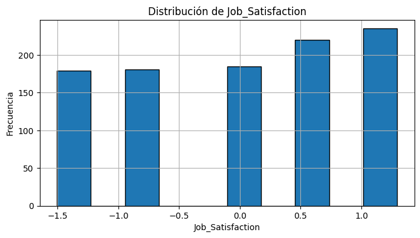

```
==================================================

Tabla de distribución de frecuencias para Performance_Rating:
Performance_Rating
(-1.353, -1.085]     246
(-1.085, -0.82]        0
(-0.82, -0.555]        0
(-0.555, -0.289]     249
(-0.289, -0.0239]      0
(-0.0239, 0.241]       0
(0.241, 0.507]       237
(0.507, 0.772]         0
(0.772, 1.037]         0
(1.037, 1.303]       268
Name: count, dtype: int64
```

[10 more figures not shown]

```python
for column in numeric_columns:
    # Crear tabla de frecuencias
    bins = 10
    freq_table = pd.cut(df[column], bins=bins).value_counts().sort_index()

    # Mostrar tabla
    print(f"Tabla de distribución de frecuencias para {column}:")
    print(freq_table)

    # Visualizar histograma
    plt.figure(figsize=(8, 4))
    df[column].hist(bins=bins, edgecolor='black')
    plt.title(f"Distribución de {column}")
    plt.xlabel(column)
    plt.ylabel("Frecuencia")
    plt.show()

    print("\n" + "="*50 + "\n")
```

# Analisis.

## Librerías

Las librerías mas usadas en este trabajo son:

- `pandas`
- `matplotlib`
- `numpy`
- `scipy`
- `seaborn`

`Seaborn` y `Matplotlib` nos ayudaron en la graficación y muestreo de resultados

`numpy` y `scipy` en cuestiones matematicas. `pandas` para la lectura del archivo csv y crear nuevos dataframes

## Resultados

Se realiza un análisis estadístico exploratorio de los datos transformados, que incluye:

- Número de valores por cada variable numérica transformada vs. original.
- Medidas de tendencia central (media, mediana, moda) de cada variable numérica transformada.
- Medidas de dispersión (rango, varianza, desviación estándar, coeficiente de variación, IQR).
- Medidas de posición (percentiles, mínimo, máximo).
- Sesgo y curtosis de cada variable numérica transformada.
- Correlación entre pares de variables cuantitativas transformadas.